# Practice Quiz 3

Caroline Goodman

2022-09-25

## Create a 70:20:10 partition for training, validation and test data.

```r
Dat <- read.csv("~/Desktop/MATH 440 - Statistical Learning/diabetes.csv")
source("~/Desktop/MATH 440 - Statistical Learning/myfunctions.R")

# create training and testing data

RNGkind (sample.kind = "Rounding")
set.seed(0) ## set seed so that you get same partition each time
p3 <- partition.3(Dat, 0.7, 0.2) ## creating 70:20:10 partition
training.data <- p3$data.train
validation.data <- p3$data.val
test.data <- p3$data.test
```

## Fit a logistic regression model on the training data for predicting outcome using the other regressors.

## Using alpha=0.05, identify the significant predictors.

Answer from Output: Logistic Regression Model: $y = 0.1306*Pregnancies + 0.0378*Glucose - 0.0126*BloodPressure$ $- 0.0029*SkinThickness - 0.0018*Insulin + 0.0890*BMI$ $+ 0.7763*DiabetesPedigreeFunction + 0.0138*Age$

Signficant Predictors: Pregnancies, Glucose, Blood Pressure, BMI, DiabetesPedigreeFunction

```r
logistic.model <- glm(Outcome ~ ., family = binomial(link = 'logit'), data = training.data)
summary(logistic.model)
```

```
##
## Call:
## glm(formula = Outcome ~ ., family = binomial(link = "logit"),
##     data = training.data)
##
## Deviance Residuals:
##     Min       1Q   Median       3Q      Max
## -2.3291  -0.7445  -0.4044   0.7176   2.8570
##
## Coefficients:
##                           Estimate Std. Error z value Pr(>|z|)
## (Intercept)              -8.471845   0.879402  -9.634  < 2e-16 ***
## Pregnancies               0.130599   0.038703   3.374  0.00074 ***
## Glucose                   0.037802   0.004638   8.150 3.63e-16 ***
## BloodPressure            -0.012592   0.006369  -1.977  0.04802 *
## SkinThickness            -0.002908   0.008148  -0.357  0.72118
## Insulin                  -0.001828   0.001048  -1.745  0.08106 .
## BMI                       0.088992   0.018143   4.905 9.35e-07 ***
## DiabetesPedigreeFunction  0.776254   0.368768   2.105  0.03529 *
## Age                       0.013772   0.011093   1.241  0.21442
## ---
## Signif. codes:  0 '***' 0.001 '**' 0.01 '*' 0.05 '.' 0.1 ' ' 1
##
## (Dispersion parameter for binomial family taken to be 1)
##
##     Null deviance: 696.28  on 537  degrees of freedom
## Residual deviance: 508.39  on 529  degrees of freedom
## AIC: 526.39
##
## Number of Fisher Scoring iterations: 5
```

```r
confint(logistic.model)
```

```
##                                  2.5 %        97.5 %
## (Intercept)              -10.274691662 -6.8219379296
## Pregnancies                0.055635378  0.2076818855
## Glucose                    0.029014342  0.0472283048
## BloodPressure             -0.025276030 -0.0002025233
## SkinThickness             -0.018790613  0.0131653446
## Insulin                   -0.003912405  0.0002216761
## BMI                        0.054588091  0.1258043277
## DiabetesPedigreeFunction   0.068806136  1.5147705447
## Age                       -0.008129150  0.0355363027
```

```r
exp(confint.default(logistic.model))
```

```
##                                 2.5 %      97.5 %
## (Intercept)              3.734014e-05 0.001172931
## Pregnancies              1.056268e+00 1.229313708
## Glucose                  1.029128e+00 1.048009563
## BloodPressure            9.752374e-01 0.999890101
## SkinThickness            9.812987e-01 1.013148022
## Insulin                  9.961261e-01 1.000225726
## BMI                      1.054885e+00 1.132641037
## DiabetesPedigreeFunction 1.054939e+00 4.477321978
## Age                      9.920617e-01 1.036151792
```

## How does the odds of being diagnosed with diabetes change if there is an one unit increase in BMI?

Answer from Output: 1.093072

```r
exp(0.088992)
```

```
## [1] 1.093072
```

## How does the odds of being diagnosed with diabetes change if age increases by 10 years?

Answer from Output: 1.147654

```r
exp(10 * 0.013772)
```

```
## [1] 1.147654
```

## For a 50 year old person with no pregnancies and Glucose = 90, BloodPressure = 74, SkinThickness = 23, Insulin = 0, BMI = 33, DiabetesPedigreeFunction = 0.7, predict the outcome. Use cutoff = 0.5.

```r
library(caret)
x0 <- data.frame(Glucose = 90, BloodPressure = 74, SkinThickness = 23, Insulin = 0,  BMI = 33,  DiabetesPedigreeFunction = 0.7, Pregnancies = 0, Age = 50)
predict(logistic.model, newdata = x0, type = "response")
```

```
##         1
## 0.1301474
```

## Create a confusion matrix on the test data. Report overall accuracy, sensitivity, specificity, and Kappa statistic.

Answer from Output: Accuracy : 0.8158 Sensitivity : 0.7083  
Specificity : 0.8654 Kappa : 0.5737

```r
pred.prob.test <- predict(logistic.model, newdata = test.data,type = "response")
pred.y.test <- ifelse(pred.prob.test > 0.5, 1, 0) # using cutoff = 0.5
confusionMatrix(as.factor(pred.y.test), as.factor(test.data$Outcome),
                positive = "1")
```

```
## Confusion Matrix and Statistics
##
##           Reference
## Prediction  0  1
##          0 45  7
##          1  7 17
##
##                Accuracy : 0.8158
##                  95% CI : (0.7103, 0.8955)
##     No Information Rate : 0.6842
##     P-Value [Acc > NIR] : 0.007432
##
##                   Kappa : 0.5737
##
##  Mcnemar's Test P-Value : 1.000000
##
##             Sensitivity : 0.7083
##             Specificity : 0.8654
##          Pos Pred Value : 0.7083
##          Neg Pred Value : 0.8654
##              Prevalence : 0.3158
##          Detection Rate : 0.2237
##    Detection Prevalence : 0.3158
##       Balanced Accuracy : 0.7869
##
##        'Positive' Class : 1
##
```

## Try different cutoff values (0.1, 0.2, 0.3, 0.4, 0.5, 0.6, 0.7, 0.8, 0.9) and create a confusion matrix for validation data. Select the best cutoff for this problem based on the Kappa coefficient. Report the best cutoff.

```r
pred.prob.validation <- predict(logistic.model, newdata = validation.data, type = "response")
pred.y.validation <- ifelse(pred.prob.validation > 0.1, 1, 0) # using cutoff value 0.1
confusionMatrix(as.factor(pred.y.validation), as.factor(validation.data$Outcome), positive = "1")
```

```
## Confusion Matrix and Statistics
##
##           Reference
## Prediction  0  1
##          0 27  2
##          1 71 54
##
##                Accuracy : 0.526
##                  95% CI : (0.444, 0.6069)
##     No Information Rate : 0.6364
##     P-Value [Acc > NIR] : 0.9981
##
##                   Kappa : 0.1897
##
##  Mcnemar's Test P-Value : 1.737e-15
##
##             Sensitivity : 0.9643
##             Specificity : 0.2755
##          Pos Pred Value : 0.4320
##          Neg Pred Value : 0.9310
##              Prevalence : 0.3636
##          Detection Rate : 0.3506
##    Detection Prevalence : 0.8117
##       Balanced Accuracy : 0.6199
##
##        'Positive' Class : 1
##
```

```r
pred.prob.validation <- predict(logistic.model, newdata = validation.data, type = "response")
pred.y.validation <- ifelse(pred.prob.validation > 0.2, 1, 0) # using cutoff value 0.2
confusionMatrix(as.factor(pred.y.validation), as.factor(validation.data$Outcome), positive = "1")
```

```
## Confusion Matrix and Statistics
##
##           Reference
## Prediction  0  1
##          0 57  4
##          1 41 52
##
##                Accuracy : 0.7078
##                  95% CI : (0.6292, 0.7782)
##     No Information Rate : 0.6364
##     P-Value [Acc > NIR] : 0.03772
##
##                   Kappa : 0.4469
##
##  Mcnemar's Test P-Value : 8.025e-08
##
##             Sensitivity : 0.9286
##             Specificity : 0.5816
##          Pos Pred Value : 0.5591
##          Neg Pred Value : 0.9344
##              Prevalence : 0.3636
##          Detection Rate : 0.3377
##    Detection Prevalence : 0.6039
##       Balanced Accuracy : 0.7551
##
##        'Positive' Class : 1
##
```

```r
pred.prob.validation <- predict(logistic.model, newdata = validation.data, type = "response")
pred.y.validation <- ifelse(pred.prob.validation > 0.3, 1, 0) # using cutoff value 0.3
confusionMatrix(as.factor(pred.y.validation), as.factor(validation.data$Outcome), positive = "1")
```

```
## Confusion Matrix and Statistics
##
##           Reference
## Prediction  0  1
##          0 71  8
##          1 27 48
##
##                Accuracy : 0.7727
##                  95% CI : (0.6984, 0.8363)
##     No Information Rate : 0.6364
##     P-Value [Acc > NIR] : 0.0001946
##
##                   Kappa : 0.5422
##
##  Mcnemar's Test P-Value : 0.0023458
##
##             Sensitivity : 0.8571
##             Specificity : 0.7245
##          Pos Pred Value : 0.6400
##          Neg Pred Value : 0.8987
##              Prevalence : 0.3636
##          Detection Rate : 0.3117
##    Detection Prevalence : 0.4870
##       Balanced Accuracy : 0.7908
##
##        'Positive' Class : 1
##
```

```r
pred.prob.validation <- predict(logistic.model, newdata = validation.data, type = "response")
pred.y.validation <- ifelse(pred.prob.validation > 0.4, 1, 0) # using cutoff value 0.4
confusionMatrix(as.factor(pred.y.validation), as.factor(validation.data$Outcome), positive = "1")
```

```
## Confusion Matrix and Statistics
##
##           Reference
## Prediction  0  1
##          0 77 12
##          1 21 44
##
##                Accuracy : 0.7857
##                  95% CI : (0.7124, 0.8477)
##     No Information Rate : 0.6364
##     P-Value [Acc > NIR] : 4.573e-05
##
##                   Kappa : 0.5524
##
##  Mcnemar's Test P-Value : 0.1637
##
##             Sensitivity : 0.7857
##             Specificity : 0.7857
##          Pos Pred Value : 0.6769
##          Neg Pred Value : 0.8652
##              Prevalence : 0.3636
##          Detection Rate : 0.2857
##    Detection Prevalence : 0.4221
##       Balanced Accuracy : 0.7857
##
##        'Positive' Class : 1
##
```

```r
pred.prob.validation <- predict(logistic.model, newdata = validation.data, type = "response")
pred.y.validation <- ifelse(pred.prob.validation > 0.5, 1, 0) # using cutoff value 0.5
confusionMatrix(as.factor(pred.y.validation), as.factor(validation.data$Outcome), positive = "1")
```

```
## Confusion Matrix and Statistics
##
##           Reference
## Prediction  0  1
##          0 79 21
##          1 19 35
##
##                Accuracy : 0.7403
##                  95% CI : (0.6635, 0.8075)
##     No Information Rate : 0.6364
##     P-Value [Acc > NIR] : 0.003999
##
##                   Kappa : 0.4344
##
##  Mcnemar's Test P-Value : 0.874367
##
##             Sensitivity : 0.6250
##             Specificity : 0.8061
##          Pos Pred Value : 0.6481
##          Neg Pred Value : 0.7900
##              Prevalence : 0.3636
##          Detection Rate : 0.2273
##    Detection Prevalence : 0.3506
##       Balanced Accuracy : 0.7156
##
##        'Positive' Class : 1
##
```

```r
pred.prob.validation <- predict(logistic.model, newdata = validation.data, type = "response")
pred.y.validation <- ifelse(pred.prob.validation > 0.6, 1, 0) # using cutoff value 0.6
confusionMatrix(as.factor(pred.y.validation), as.factor(validation.data$Outcome), positive = "1")
```

```
## Confusion Matrix and Statistics
##
##           Reference
## Prediction  0  1
##          0 82 24
##          1 16 32
##
##                Accuracy : 0.7403
##                  95% CI : (0.6635, 0.8075)
##     No Information Rate : 0.6364
##     P-Value [Acc > NIR] : 0.003999
##
##                   Kappa : 0.4211
##
##  Mcnemar's Test P-Value : 0.268382
##
##             Sensitivity : 0.5714
##             Specificity : 0.8367
##          Pos Pred Value : 0.6667
##          Neg Pred Value : 0.7736
##              Prevalence : 0.3636
##          Detection Rate : 0.2078
##    Detection Prevalence : 0.3117
##       Balanced Accuracy : 0.7041
##
##        'Positive' Class : 1
##
```

```r
pred.prob.validation <- predict(logistic.model, newdata = validation.data, type = "response")
pred.y.validation <- ifelse(pred.prob.validation > 0.7, 1, 0) # using cutoff value 0.7
confusionMatrix(as.factor(pred.y.validation), as.factor(validation.data$Outcome), positive = "1")
```

```
## Confusion Matrix and Statistics
##
##           Reference
## Prediction  0  1
##          0 90 30
##          1  8 26
##
##                Accuracy : 0.7532
##                  95% CI : (0.6774, 0.8191)
##     No Information Rate : 0.6364
##     P-Value [Acc > NIR] : 0.0013172
##
##                   Kappa : 0.4178
##
##  Mcnemar's Test P-Value : 0.0006577
##
##             Sensitivity : 0.4643
##             Specificity : 0.9184
##          Pos Pred Value : 0.7647
##          Neg Pred Value : 0.7500
##              Prevalence : 0.3636
##          Detection Rate : 0.1688
##    Detection Prevalence : 0.2208
##       Balanced Accuracy : 0.6913
##
##        'Positive' Class : 1
##
```

```r
pred.prob.validation <- predict(logistic.model, newdata = validation.data, type = "response")
pred.y.validation <- ifelse(pred.prob.validation > 0.8, 1, 0) # using cutoff value 0.8
confusionMatrix(as.factor(pred.y.validation), as.factor(validation.data$Outcome), positive = "1")
```

```
## Confusion Matrix and Statistics
##
##           Reference
## Prediction  0  1
##          0 96 40
##          1  2 16
##
##                Accuracy : 0.7273
##                  95% CI : (0.6497, 0.7958)
##     No Information Rate : 0.6364
##     P-Value [Acc > NIR] : 0.01072
##
##                   Kappa : 0.3104
##
##  Mcnemar's Test P-Value : 1.135e-08
##
##             Sensitivity : 0.2857
##             Specificity : 0.9796
##          Pos Pred Value : 0.8889
##          Neg Pred Value : 0.7059
##              Prevalence : 0.3636
##          Detection Rate : 0.1039
##    Detection Prevalence : 0.1169
##       Balanced Accuracy : 0.6327
##
##        'Positive' Class : 1
##
```

```r
pred.prob.validation <- predict(logistic.model, newdata = validation.data, type = "response")
pred.y.validation <- ifelse(pred.prob.validation > 0.9, 1, 0) # using cutoff value 0.9
confusionMatrix(as.factor(pred.y.validation), as.factor(validation.data$Outcome), positive = "1")
```

```
## Confusion Matrix and Statistics
##
##           Reference
## Prediction  0  1
##          0 97 51
##          1  1  5
##
##                Accuracy : 0.6623
##                  95% CI : (0.5818, 0.7365)
##     No Information Rate : 0.6364
##     P-Value [Acc > NIR] : 0.2806
##
##                   Kappa : 0.0978
##
##  Mcnemar's Test P-Value : 1.083e-11
##
##             Sensitivity : 0.08929
##             Specificity : 0.98980
##          Pos Pred Value : 0.83333
##          Neg Pred Value : 0.65541
##              Prevalence : 0.36364
##          Detection Rate : 0.03247
##    Detection Prevalence : 0.03896
##       Balanced Accuracy : 0.53954
##
##        'Positive' Class : 1
##
```

## Combine training and validation data. Fit logistic regression model on the combined data using the best cutoff. Test this model on the test data and report overall accuracy, sensitivity, specificity, and Kappa statistic.

Answer from Output:

Accuracy : 0.7587  
Sensitivity : 0.6762  
Specificity : 0.8036  
Kappa : 0.4758

```r
combined <- rbind(training.data, validation.data)
pred.prob.combined <- predict(logistic.model, newdata = combined, type = "response")
pred.y.combined <- ifelse(pred.prob.combined > 0.4, 1, 0) # using cutoff value 0.4
confusionMatrix(as.factor(pred.y.combined), as.factor(combined$Outcome), positive = "1")
```

```
## Confusion Matrix and Statistics
##
##           Reference
## Prediction   0   1
##          0 360  79
##          1  88 165
##
##                Accuracy : 0.7587
##                  95% CI : (0.725, 0.7901)
##     No Information Rate : 0.6474
##     P-Value [Acc > NIR] : 1.822e-10
##
##                   Kappa : 0.4758
##
##  Mcnemar's Test P-Value : 0.5359
##
##             Sensitivity : 0.6762
##             Specificity : 0.8036
##          Pos Pred Value : 0.6522
##          Neg Pred Value : 0.8200
##              Prevalence : 0.3526
##          Detection Rate : 0.2384
##    Detection Prevalence : 0.3656
##       Balanced Accuracy : 0.7399
##
##        'Positive' Class : 1
##
```

## Create a ROC chart for the model fitted in the above question on the test data. Report the area under the curve.

Answer from Output: area under the curve on the test data: 0.8606  
area under the curve on the combined data: 0.8355

```r
library(pROC)
# on test data
r <- roc(test.data$Outcome, pred.prob.test)
```

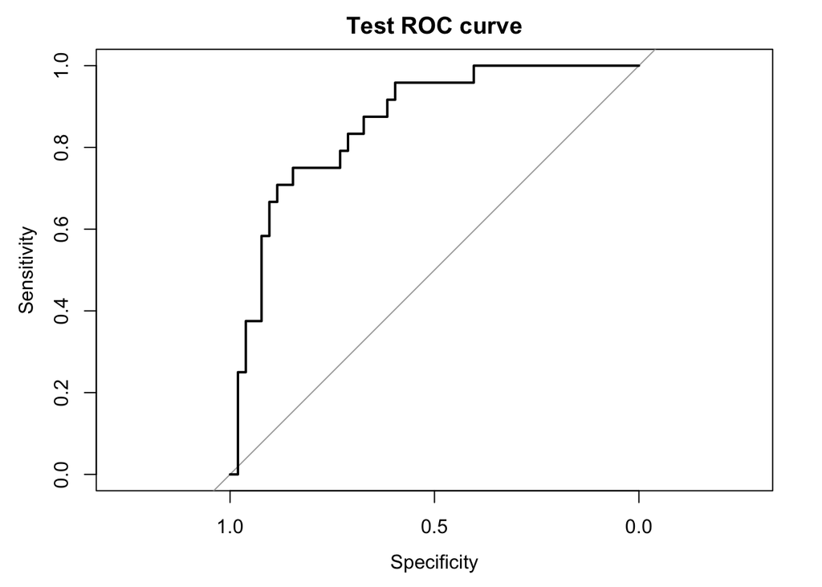

```r
plot.roc(r, main = "Test ROC curve")
```

```r
auc(r)
```

```
## Area under the curve: 0.8606
```

```r
# on combined data
r <- roc(combined$Outcome, pred.prob.combined)
```

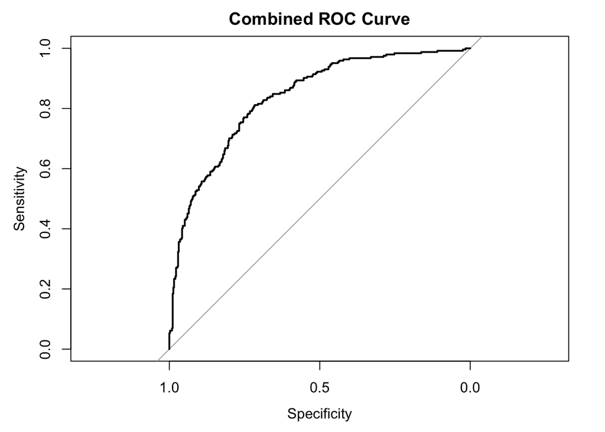

```r
plot.roc(r, main = "Combined ROC Curve")
```

```r
auc(r)
```

```
## Area under the curve: 0.8355
```

## Create a lift chart for the model fitted in the above question on the test data. What percentage of people with positive diabetes outcome is captured in the top 30%?

Answer from Output: 66.7% of people with positive diabetes outcome is captured in the top 30%

```r
library(gains)
gain <- gains(test.data$Outcome, pred.prob.test)
gain
```

```
## Depth                            Cume   Cume Pct                     Mean
##  of           Cume     Mean      Mean   of Total    Lift   Cume     Model
## File     N      N      Resp      Resp      Resp    Index   Lift     Score
## -------------------------------------------------------------------------
##    9     7      7      0.86      0.86      25.0%     271    271      0.93
##   20     8     15      0.62      0.73      45.8%     198    232      0.81
##   29     7     22      0.71      0.73      66.7%     226    230      0.66
##   39     8     30      0.25      0.60      75.0%      79    190      0.42
##   50     8     38      0.38      0.55      87.5%     119    175      0.32
##   59     7     45      0.29      0.51      95.8%      90    162      0.23
##   70     8     53      0.00      0.43      95.8%       0    137      0.17
##   79     7     60      0.14      0.40     100.0%      45    127      0.12
##   89     8     68      0.00      0.35     100.0%       0    112      0.10
##  100     8     76      0.00      0.32     100.0%       0    100      0.05
```

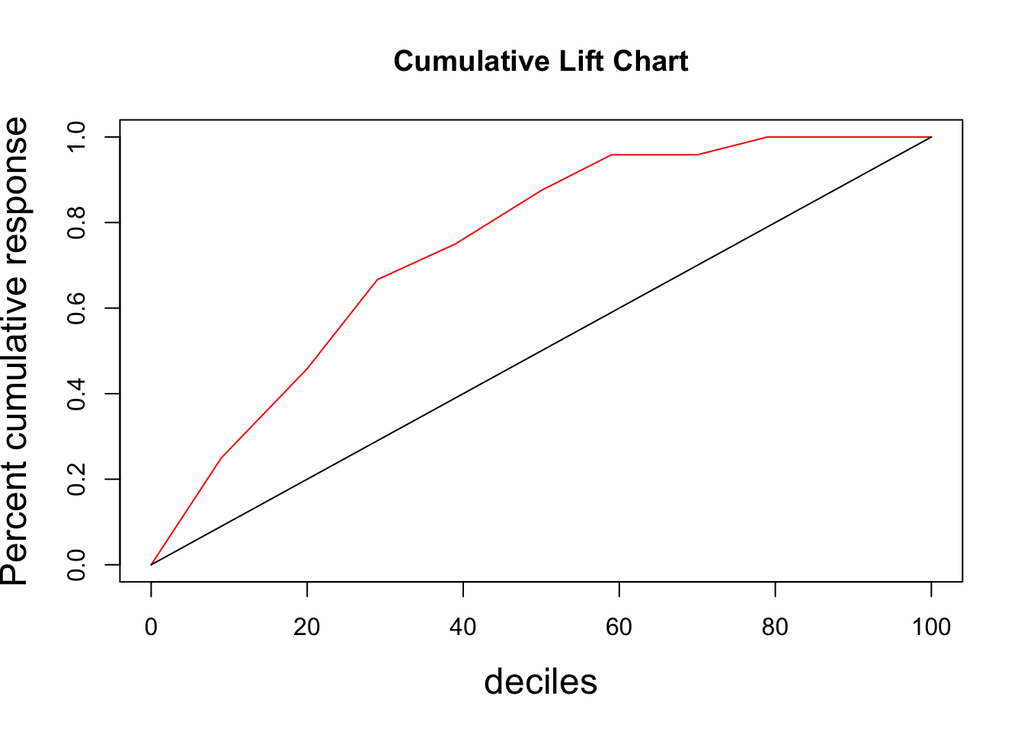

```r
x <- c(0, gain$depth)
pred.y <- c(0, gain$cume.pct.of.total)
avg.y <- c(0, gain$depth/100)
plot(x, pred.y, main = "Cumulative Lift Chart", xlab = "deciles", ylab = "Percent cumulative response", type = "l", col = "red", cex.lab = 1.5)
lines(x, avg.y, type = "l")
```